# [R] fit polynomial regression in R

Zhenguo Zhang

2019-07-12

In R, we can fit a polynomial model by combinative use two functions *poly()* and *lm()*.

## Setup

Let’s start with using the R internal data *cars*:

```r
data(cars)
x<-cars$speed # use the speed as predictor
y<-cars$dist # use the dist as response
```

## Fit the models

Now, let’s get the polynomials for the variable *x* using the degree 3:

```r
x1<-poly(x, 3, raw=TRUE)
x2<-poly(x, 3, raw=FALSE)
# check the resulted polynomials
head(x)
```

```
## [1] 4 4 7 7 8 9
```

```r
head(x1)
```

```
##      1  2   3
## [1,] 4 16  64
## [2,] 4 16  64
## [3,] 7 49 343
## [4,] 7 49 343
## [5,] 8 64 512
## [6,] 9 81 729
```

```r
head(x2)
```

```
##               1          2           3
## [1,] -0.3079956 0.41625480 -0.35962151
## [2,] -0.3079956 0.41625480 -0.35962151
## [3,] -0.2269442 0.16583013  0.05253037
## [4,] -0.2269442 0.16583013  0.05253037
## [5,] -0.1999270 0.09974267  0.11603440
## [6,] -0.1729098 0.04234892  0.15002916
```

*poly()* returns a matrix, with the first column corresponds to original data *x*, second column to the quadratic term *x^2*, third column to the cubic term *x^3*, etc.

As you see, there are two ways to generate polynomial data for a variable using *poly()* in R, depending on the option *raw* is *TRUE* or *FALSE*. When it is *TRUE*, the polynomials are simply *x* to the power of respective degrees. When it is *FALSE*, the polynomials are further normalized to be orthogonal among each other. We will see how different these two ways are in model fitting below.

```r
m1<-lm(y ~ x1)
m2<-lm(y ~ x2)
# summarize the models
summary(m1)
```

```
##
## Call:
## lm(formula = y ~ x1)
##
## Residuals:
##     Min      1Q  Median      3Q     Max
## -26.670  -9.601  -2.231   7.075  44.691
##
## Coefficients:
##              Estimate Std. Error t value Pr(>|t|)
## (Intercept) -19.50505   28.40530  -0.687    0.496
## x11           6.80111    6.80113   1.000    0.323
## x12          -0.34966    0.49988  -0.699    0.488
## x13           0.01025    0.01130   0.907    0.369
##
## Residual standard error: 15.2 on 46 degrees of freedom
## Multiple R-squared:  0.6732, Adjusted R-squared:  0.6519
## F-statistic: 31.58 on 3 and 46 DF,  p-value: 3.074e-11
```

```r
summary(m2)
```

```
##
## Call:
## lm(formula = y ~ x2)
##
## Residuals:
##     Min      1Q  Median      3Q     Max
## -26.670  -9.601  -2.231   7.075  44.691
##
## Coefficients:
##             Estimate Std. Error t value Pr(>|t|)
## (Intercept)    42.98       2.15  19.988  < 2e-16 ***
## x21           145.55      15.21   9.573  1.6e-12 ***
## x22            23.00      15.21   1.512    0.137
## x23            13.80      15.21   0.907    0.369
## ---
## Signif. codes:  0 '***' 0.001 '**' 0.01 '*' 0.05 '.' 0.1 ' ' 1
##
## Residual standard error: 15.2 on 46 degrees of freedom
## Multiple R-squared:  0.6732, Adjusted R-squared:  0.6519
## F-statistic: 31.58 on 3 and 46 DF,  p-value: 3.074e-11
```

As shown above, the two models are overall the same, both having P value = 3.074e-11, F-stat=31.58, and adjusted R-squared=0.6519. However, the coefficients of the predictors (x, x^2, and x^3) are different, as expected. More importantly, for the model *m1*, none of the coefficients are significant, while for *m2*, the coefficient of *x* is significant. This can be explained as: in model *m1*, the predictors are highly correlated, so the variance of the coefficients is much larger than that in model *m2* whose predictors are orthogonal.

## Predict with new data

Let’s see how to make predictions using the fitted models.

```r
newx<-seq(min(x),max(x),length.out = 100)
# convert the newx to polynomials first
newx1<-predict(x1, newdata = newx) # here x1 is also "poly" class object
newx2<-predict(x2, newdata = newx)
# then make predictions using the converted data
y1<-predict(m1, newdata = list(x1=newx1)) # the newdata follows the format of the original model fitting
y2<-predict(m2, newdata = list(x2=newx2))
```

As you see in the plots below, the predictions from the two models are essentially the same and fit the original data very well.

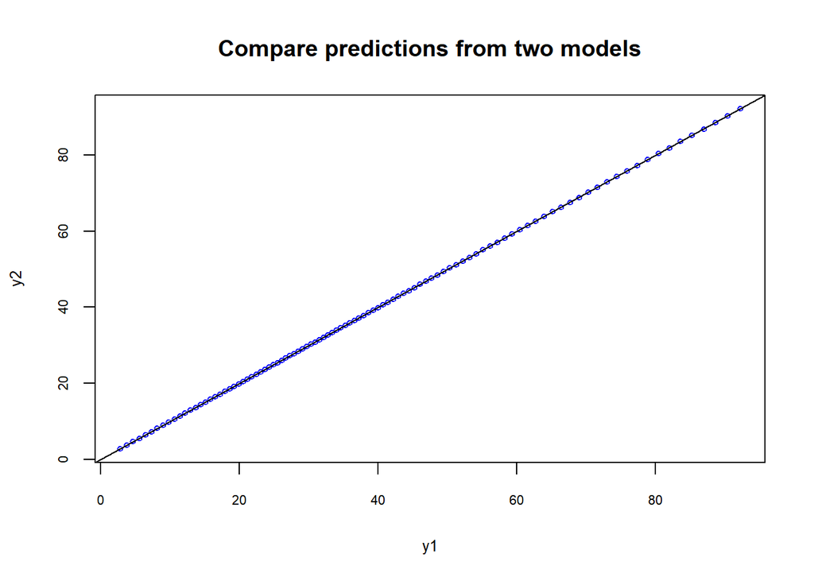

```r
# compare y1 and y2
plot(y1,y2, cex=0.6, col="blue", cex.lab=0.8, cex.axis=0.7, main="Compare predictions from two models")
abline(0,1,col="black")
```

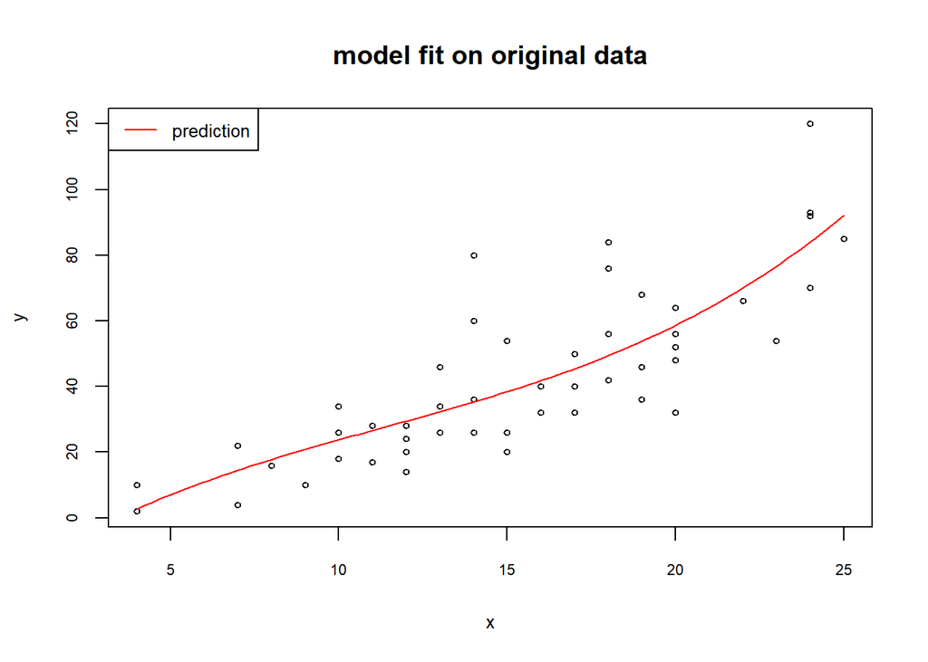

```r
# also check the fit of the prediction with the original data
plot(x,y, cex=0.6, cex.lab=0.8, cex.axis=0.7, main="model fit on original data")
lines(newx,y1,col="red")
legend("topleft",legend="prediction", lty="solid", col="red", cex=0.8)
```

## Conclusions

1. one can use *poly()* and *lm()* to fit polynomial models in R.
2. actually, one can directly specify *lm(y ~ poly(x, degree))* to fit models. In this case, the new data should also be given as raw x without any polynomial conversion.
3. raw and orthogonal transformed polynomials make difference only in the term cofficients of models, but have no effect on the predictions.